# Uni cars data story

## To all the Car Geeks

I observed parked cars at various University of Auckland buildings - OGGB, Engineering faculty, Science faculty and General library. I recorded the brand, colour, origin, and where I saw them. This data will show approximately - what car brand (and origin for example japanese, german) is the most popular (I was pretty sure it will be toyota :D ) on campus

## Most popular car brands

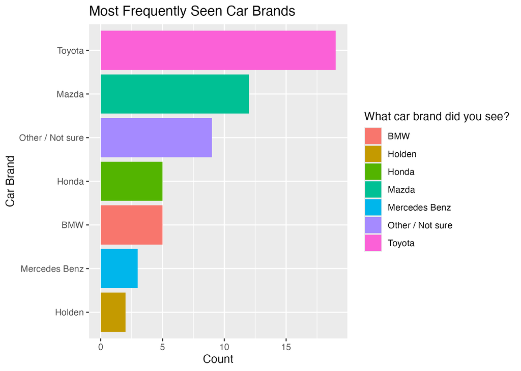

*Alt-text: Horizontal bar chart showing which car brands were observed most on campus.*

Toyota, as expected was the most popular brand on campus 😅 I guess it should be true not only in the city centre..

## Car colour distribution by location

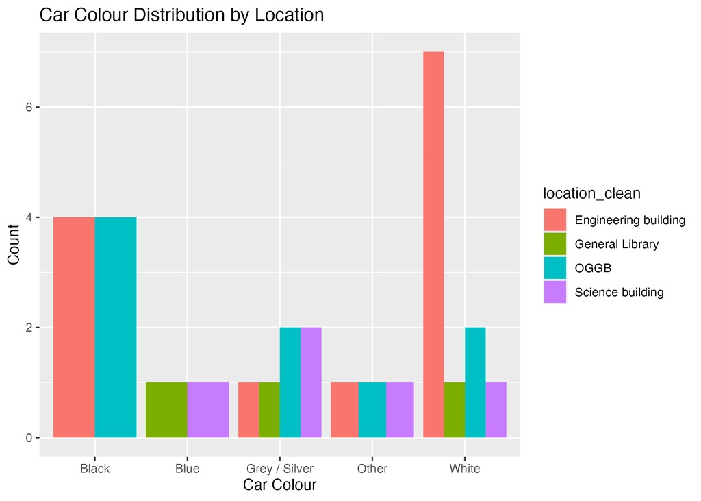

*Alt-text: Grouped bar chart showing how car colours differ by building location.*

**Black** and **white** were the most common colours overall, but Science and the General Library had a more balanced distribution with more grey/silver and blue cars (which were toyotas)

## Car counts by brand type

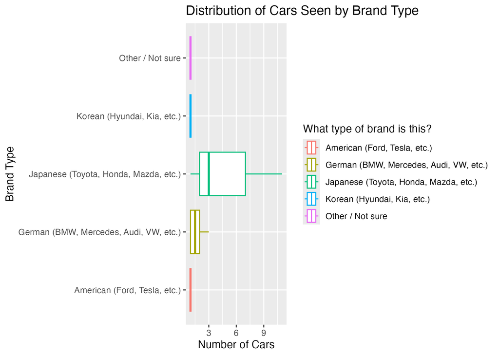

*Alt-text: Boxplot comparing number of cars seen per day for each brand origin (Japanese, German, etc.)*

**Japanese cars** were the most frequently seen, with a wide range of daily counts. German brands were also common, but less frequent than Japanese brands.